# Veronica Scratch2

Veronica Marquez

Check Location of the file

```r
getwd()
```

```
[1] "/Users/veronicamarquez/Desktop/Dr.D Ecology Bias SC/MA321-Daneshgar"
```

run the libraries

```r
library(mosaic)
library(readxl)
library(gplots)
library(nhstplot)
```

Read in the Data from the excel file provided

```r
EcologyBias_Daneshgar_Popo_2_ <- read_excel("/Users/veronicamarquez/Desktop/Dr.D Ecology Bias SC/MA321-Daneshgar/EcologyBias.Daneshgar.Popo.xlsx")
View(EcologyBias_Daneshgar_Popo_2_)
# here we are renaming the file
EcologyBias <- EcologyBias_Daneshgar_Popo_2_[1:175, ]
```

# Ecosystem

*CASE 1* (no Square mileage) HO: The probability of each Ecosystem being represented in a journal entry is the same HA: The probability of each Ecosystem being represented in a journal entry is not the same *Case 2* (with Square Mileage) HO: The probability of each Ecosystem being represented in a journal entry is the same as square mileage HA: The probability of each Ecosystem being represented in a journal entry is not the same as square mileage

Going through the data to see how many of each ecosystem type are found

```r
#what this code is doing is basically counting each time a data entry matches the "word" we are looking for
cat("# of Journals in Marine: ", count(EcologyBias$`Marine, Terrestrial, Freshwater, Mixed` == "Marine"), "\n")
```

```
# of Journals in Marine:  20
```

```r
cat("# of Journals in Terrestrial: ", count(EcologyBias$`Marine, Terrestrial, Freshwater, Mixed` == "Terrestrial"), "\n")
```

```
# of Journals in Terrestrial:  127
```

```r
cat("# of Journals in Frshwater: ", count(EcologyBias$`Marine, Terrestrial, Freshwater, Mixed` == "Freshwater"), "\n")
```

```
# of Journals in Frshwater:  12
```

```r
cat("# of Journals in Mixed: ", count(EcologyBias$`Marine, Terrestrial, Freshwater, Mixed` == "Mixed"), "\n")
```

```
# of Journals in Mixed:  16
```

Notice here that there is a noticeable difference in the amount of articles that contain each ecosystem. If we take the sum of the data entries and divide it by the number of ecosystems we see that on average if they were given a “fair” chance of being chosen we would get an average number of 43 per ecosystem. But based on the results of the observed data we could conclude that there is some distinct difference between all th data. Could this allow me to conclude right of the bat that there is some noticeable bias involved? That could mean that we are basing all this on “self-opinion” and “assumption”

using tally() function

```r
tally(EcologyBias$`Marine, Terrestrial, Freshwater, Mixed`)
```

```
X
 Freshwater      Marine       Mixed Terrestrial
         12          20          16         127
```

tally function is going into the data file finding the column named “Marine, Terrestrial, Freshwater, Mixed” and tallying each type of ecosystem. This is another good way to check that the count matches and we haven’t overlooked any other type of ecosystem in that column

Chi-Squared Test of Ecosystem (Po defines) *Case 1* *Note: that here we removed mixed because of our null and alt hypothesis are based on giving each type of ecosystem has a fair chance, so mixed wouldn’t help us prove their is a difference between them.* What is Chi-Sq? Chi-squared test is used to determine whether there is a statistically significant difference between the expected frequencies and the observed frequencies in one or more categories of a contingency table

```r
# Creating a vector
eco.po <- as.vector(EcologyBias$`Marine, Terrestrial, Freshwater, Mixed`)
eco.po
```

```
  [1] "Terrestrial" "Terrestrial" "Terrestrial" "Terrestrial" "Terrestrial" "Terrestrial" "Terrestrial" "Terrestrial" "Terrestrial" "Terrestrial"
 [11] "Terrestrial" "Terrestrial" "Terrestrial" "Terrestrial" "Marine"      "Marine"      "Terrestrial" "Terrestrial" "Terrestrial" "Terrestrial"
 [21] "Terrestrial" "Terrestrial" "Terrestrial" "Terrestrial" "Mixed"       "Terrestrial" "Terrestrial" "Freshwater"  "Freshwater"  "Mixed"
 [31] "Mixed"       "Terrestrial" "Terrestrial" "Terrestrial" "Marine"      "Terrestrial" "Terrestrial" "Terrestrial" "Terrestrial" "Terrestrial"
 [41] "Terrestrial" "Terrestrial" "Terrestrial" "Terrestrial" "Terrestrial" "Terrestrial" "Terrestrial" "Mixed"       "Terrestrial" "Freshwater"
 [51] "Terrestrial" "Terrestrial" "Marine"      "Terrestrial" "Terrestrial" "Terrestrial" "Terrestrial" "Terrestrial" "Terrestrial" "Terrestrial"
 [61] "Marine"      "Mixed"       "Marine"      "Terrestrial" "Terrestrial" "Terrestrial" "Terrestrial" "Terrestrial" "Terrestrial" "Terrestrial"
 [71] "Terrestrial" "Mixed"       "Terrestrial" "Mixed"       "Mixed"       "Terrestrial" "Terrestrial" "Marine"      "Terrestrial" "Terrestrial"
 [81] "Terrestrial" "Terrestrial" "Terrestrial" "Terrestrial" "Freshwater"  "Terrestrial" "Terrestrial" "Terrestrial" "Marine"      "Terrestrial"
 [91] "Mixed"       "Terrestrial" "Terrestrial" "Terrestrial" "Terrestrial" "Freshwater"  "Mixed"       "Terrestrial" "Freshwater"  "Terrestrial"
[101] "Marine"      "Terrestrial" "Terrestrial" "Mixed"       "Terrestrial" "Terrestrial" "Freshwater"  "Terrestrial" "Terrestrial" "Terrestrial"
[111] "Terrestrial" "Terrestrial" "Marine"      "Terrestrial" "Terrestrial" "Terrestrial" "Terrestrial" "Mixed"       "Terrestrial" "Terrestrial"
[121] "Terrestrial" "Terrestrial" "Terrestrial" "Mixed"       "Terrestrial" "Freshwater"  "Marine"      "Marine"      "Terrestrial" "Terrestrial"
[131] "Terrestrial" "Marine"      "Freshwater"  "Terrestrial" "Terrestrial" "Terrestrial" "Marine"      "Terrestrial" "Terrestrial" "Marine"
[141] "Terrestrial" "Freshwater"  "Marine"      "Terrestrial" "Terrestrial" "Terrestrial" "Terrestrial" "Terrestrial" "Marine"      "Terrestrial"
[151] "Mixed"       "Mixed"       "Terrestrial" "Terrestrial" "Marine"      "Terrestrial" "Terrestrial" "Terrestrial" "Terrestrial" "Terrestrial"
[161] "Terrestrial" "Mixed"       "Terrestrial" "Terrestrial" "Terrestrial" "Marine"      "Terrestrial" "Terrestrial" "Freshwater"  "Terrestrial"
[171] "Marine"      "Terrestrial" "Terrestrial" "Freshwater"  "Terrestrial"
```

```r
# removing each time "Mixed" is mentioned
remove <- c ("Mixed")

eco.po %in% remove
```

[output not shown]

```r
eco.po <- eco.po [! eco.po %in% remove]
eco.po
```

```
  [1] "Terrestrial" "Terrestrial" "Terrestrial" "Terrestrial" "Terrestrial" "Terrestrial" "Terrestrial" "Terrestrial" "Terrestrial" "Terrestrial"
 [11] "Terrestrial" "Terrestrial" "Terrestrial" "Terrestrial" "Marine"      "Marine"      "Terrestrial" "Terrestrial" "Terrestrial" "Terrestrial"
 [21] "Terrestrial" "Terrestrial" "Terrestrial" "Terrestrial" "Terrestrial" "Terrestrial" "Freshwater"  "Freshwater"  "Terrestrial" "Terrestrial"
 [31] "Terrestrial" "Marine"      "Terrestrial" "Terrestrial" "Terrestrial" "Terrestrial" "Terrestrial" "Terrestrial" "Terrestrial" "Terrestrial"
 [41] "Terrestrial" "Terrestrial" "Terrestrial" "Terrestrial" "Terrestrial" "Freshwater"  "Terrestrial" "Terrestrial" "Marine"      "Terrestrial"
 [51] "Terrestrial" "Terrestrial" "Terrestrial" "Terrestrial" "Terrestrial" "Terrestrial" "Marine"      "Marine"      "Terrestrial" "Terrestrial"
 [61] "Terrestrial" "Terrestrial" "Terrestrial" "Terrestrial" "Terrestrial" "Terrestrial" "Terrestrial" "Terrestrial" "Terrestrial" "Marine"
 [71] "Terrestrial" "Terrestrial" "Terrestrial" "Terrestrial" "Terrestrial" "Terrestrial" "Freshwater"  "Terrestrial" "Terrestrial" "Terrestrial"
 [81] "Marine"      "Terrestrial" "Terrestrial" "Terrestrial" "Terrestrial" "Terrestrial" "Freshwater"  "Terrestrial" "Freshwater"  "Terrestrial"
 [91] "Marine"      "Terrestrial" "Terrestrial" "Terrestrial" "Terrestrial" "Freshwater"  "Terrestrial" "Terrestrial" "Terrestrial" "Terrestrial"
[101] "Terrestrial" "Marine"      "Terrestrial" "Terrestrial" "Terrestrial" "Terrestrial" "Terrestrial" "Terrestrial" "Terrestrial" "Terrestrial"
[111] "Terrestrial" "Terrestrial" "Freshwater"  "Marine"      "Marine"      "Terrestrial" "Terrestrial" "Terrestrial" "Marine"      "Freshwater"
[121] "Terrestrial" "Terrestrial" "Terrestrial" "Marine"      "Terrestrial" "Terrestrial" "Marine"      "Terrestrial" "Freshwater"  "Marine"
[131] "Terrestrial" "Terrestrial" "Terrestrial" "Terrestrial" "Terrestrial" "Marine"      "Terrestrial" "Terrestrial" "Terrestrial" "Marine"
[141] "Terrestrial" "Terrestrial" "Terrestrial" "Terrestrial" "Terrestrial" "Terrestrial" "Terrestrial" "Terrestrial" "Terrestrial" "Marine"
[151] "Terrestrial" "Terrestrial" "Freshwater"  "Terrestrial" "Marine"      "Terrestrial" "Terrestrial" "Freshwater"  "Terrestrial"
```

```r
tally(eco.po)
```

```
X
 Freshwater      Marine Terrestrial
         12          20         127
```

```r
# chisq.test() will display the p-vlaue
chisq.test(tally(eco.po))
```

```
    Chi-squared test for given probabilities

data:  tally(eco.po)
X-squared = 155.58, df = 2, p-value < 2.2e-16
```

```r
# xchisq.tes() will display the p-value and display our expected values if it was fair throughout
xchisq.test(tally(eco.po))
```

```
    Chi-squared test for given probabilities

data:  x
X-squared = 155.58, df = 2, p-value < 2.2e-16

   12       20      127
(53.00)  (53.00)  (53.00)
[ 31.72] [ 20.55] [103.32]
<-5.63>  <-4.53>  <10.16>

key:
    observed
    (expected)
    [contribution to X-squared]
    <Pearson residual>
```

Creating Charts to visually show our findings

2 Types of Chart with Expected Values *given all ecosystems have a fair chance of being selected* not based on sqr mileage just based on the “n”

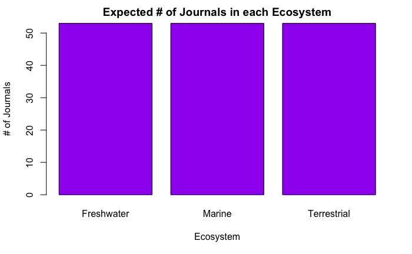

```r
Exp <- c(53,53,53)
Eco <- c("Freshwater", "Marine", "Terrestrial")
barPlot1 <- barplot(Exp, names.arg = Eco, xlab ="Ecosystem", ylab = " # of Journals", col = "purple", main = "Expected # of Journals in each Ecosystem", border = "black")
```

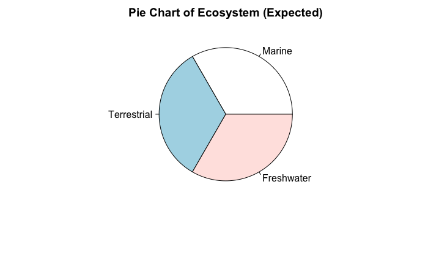

```r
slicesExp <- c(53,53,53)
lbls <- c("Marine", "Terrestrial", "Freshwater")
pie(slicesExp, labels = lbls, main = "Pie Chart of Ecosystem (Expected)" )
```

2 Types of Chart with Observed Values

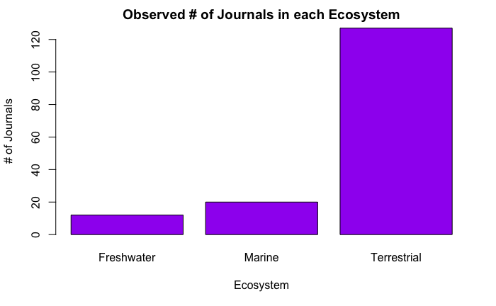

```r
Obs <- c(12, 20, 127)
EcoObs <- c("Freshwater", "Marine", "Terrestrial")
barPlot2 <- barplot(Obs, names.arg = EcoObs, xlab ="Ecosystem", ylab = " # of Journals", col = "purple", main = "Observed # of Journals in each Ecosystem", border = "black")
```

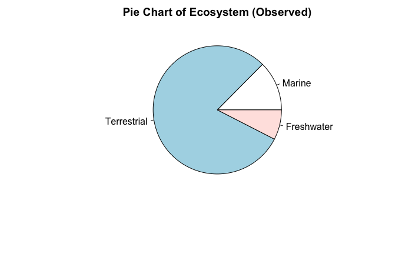

```r
slices <- c(20,127,12)
lbls <- c("Marine", "Terrestrial", "Freshwater")
pie(slices, labels = lbls, main="Pie Chart of Ecosystem (Observed)")
```

Chi-Squared Test of Ecosystem (Po defines) *Case 2* (With Square Mileage)

```r
sm.ecosystem <- c(Eco_Sqr_Mileage$`Sqr Mil (mil mi^2)`)

sm.ecosystem <- as.numeric(sm.ecosystem[1:3])

prop.cont <- sm.ecosystem/sum(sm.ecosystem)
prop.cont
```

```
[1] 0.0210000 0.6964619 0.2825381
```

```r
chisq.test(tally(eco.po), p=prop.cont)
```

```
Chi-squared approximation may be incorrect
```

```
    Chi-squared test for given probabilities

data:  tally(eco.po)
X-squared = 246.77, df = 2, p-value < 2.2e-16
```

```r
xchisq.test(tally(eco.po), p = prop.cont)
```

```
Chi-squared approximation may be incorrect
```

```
    Chi-squared test for given probabilities

data:  x
X-squared = 246.77, df = 2, p-value < 2.2e-16

   12       20      127
(  3.34) (110.74) ( 44.92)
[ 22.47] [ 74.35] [149.96]
< 4.74>  <-8.62>  <12.25>

key:
    observed
    (expected)
    [contribution to X-squared]
    <Pearson residual>
```

```r
xchisq.test(tally(eco.po),p=prop.cont, simulate.p.value = TRUE )
```

```
    Chi-squared test for given probabilities with simulated p-value (based on 2000 replicates)

data:  x
X-squared = 246.77, df = NA, p-value = 0.0004998

   12       20      127
(  3.34) (110.74) ( 44.92)
[ 22.47] [ 74.35] [149.96]
< 4.74>  <-8.62>  <12.25>

key:
    observed
    (expected)
    [contribution to X-squared]
    <Pearson residual>
```

2 Types of Charts of Expected Value based on the Square Mileage

```r
#Bar Plot
Exp <- c(3.34, 110.74, 44.92)
EcoExp <- c("Freshwater", "Marine", "Terrestrial")
barPlot2 <- barplot(Exp, names.arg = EcoExp, xlab ="Ecosystem", ylab = " # of Journals", col = "green", main = "Expected # of Journals in each Ecosystem based on Sqr. Mileage", border = "black")

#Pie Chart
slicesExp <- c(110.74,44.92,3.34)
lbls <- c("Marine", "Terrestrial", "Freshwater")
pie(slicesExp, labels = lbls, main="Expected # of Jounrals in each Ecosystem based on Sqr. Mileage")
```

[output not shown]

2 Types of Charts of Observed Values based on the Square Mileage

```r
#Bar Plot
Obs <- c(12, 20, 127)
EcoObs <- c("Freshwater", "Marine", "Terrestrial")
barPlot2 <- barplot(Obs, names.arg = EcoObs, xlab ="Ecosystem", ylab = " # of Journals", col = "green", main = "Observed # of Journals in each Ecosystem based on Sqr. Mileage", border = "black")

#Pie Chart
slices <- c(20,127,12)
lbls <- c("Marine", "Terrestrial", "Freshwater")
pie(slices, labels = lbls, main="Observed # of Jounrals in each Ecosystem based on Sqr. Mileage)")
```

[output not shown]

# Continent

*CASE 1* (no Square mileage) HO: The probability of each Continent being represented in a journal entry is the same HA: The probability of each Continent being represented in a journal entry is not the same *Case 2* (with Square Mileage) HO: The probability of each Continent being represented in a journal entry is the same as square mileage HA: The probability of each Continent being represented in a journal entry is not the same as square mileage

Cleaning our data and using tally() function to view our numbers

```r
continent.work <- as.vector(EcologyBias$`Continent where work done`)
remove <- c ("Europe & Oceania", "META ANALYSIS","META ANALYSIS!")
continent.work %in% remove
```

[output not shown]

```r
continent.work <- continent.work [! continent.work %in% remove]
continent.work[43] <- "Oceania"
continent.work[61] <- "Oceania"
continent.work <- c(continent.work[1:97], continent.work[99:168])
continent.work
```

```
  [1] "North America" "North America" "North America" "North America" "North America" "North America" "South America" "South America" "North America"
 [10] "North America" "North America" "North America" "Europe"        "South America" "Europe"        "Europe"        "Europe"        "Africa"
 [19] "North America" "Asia"          "North America" "North America" "Asia"          "North America" "Europe"        "Europe"        "North America"
 [28] "Europe"        "North America" "North America" "North America" "North America" "North America" "North America" "North America" "North America"
 [37] "North America" "South America" "North America" "North America" "North America" "Europe"        "Oceania"       "North America" "North America"
 [46] "Europe"        "North America" "North America" "North America" "Asia"          "North America" "Europe"        "Africa"        "Oceania"
 [55] "North America" "North America" "North America" "North America" "North America" "Europe"        "Oceania"       "Asia"          "Europe"
 [64] "North America" "North America" "Europe"        "North America" "North America" "Europe"        "Asia"          "North America" "Asia"
 [73] "North America" "South America" "Africa"        "North America" "North America" "South America" "North America" "North America" "South America"
 [82] "South America" "Europe"        "Australia"     "North America" "South America" "North America" "North America" "North America" "North America"
 [91] "North America" "North America" "North America" "South America" "North America" "North America" "North America" "North America" "North America"
[100] "North America" "South America" "Asia"          "North America" "North America" "North America" "North America" "North America" "North America"
[109] "Europe"        "Europe"        "Europe"        "North America" "Asia"          "North America" "Africa"        "North America" "North America"
[118] "South America" "North America" "North America" "Europe"        "North America" "Europe"        "Europe"        "North America" "North America"
[127] "North America" "North America" "South America" "Asia"          "North America" "Europe"        "Asia"          "North America" "North America"
[136] "Asia"          "Australia"     "Asia"          "Europe"        "North America" "Europe"        "Europe"        "North America" "Asia"
[145] "Europe"        "Europe"        "Europe"        "North America" "North America" "Oceania"       "North America" "Europe"        "North America"
[154] "Asia"          "North America" "Africa"        "Europe"        "Oceania"       "Europe"        "North America" "Europe"        "Europe"
[163] "North America" "North America" "North America" "North America" "Europe"
```

```r
tally(continent.work)
```

```
X
       Africa          Asia     Australia        Europe North America       Oceania South America
            5            14             2            34            94             5            13
```

Chi-Squared Tests for *CASE 1*

```r
chisq.test(tally(continent.work))
```

```
    Chi-squared test for given probabilities

data:  tally(continent.work)
X-squared = 269.39, df = 6, p-value < 2.2e-16
```

```r
xchisq.test(tally(continent.work))
```

```
    Chi-squared test for given probabilities

data:  x
X-squared = 269.39, df = 6, p-value < 2.2e-16

    5       14        2       34       94        5       13
(23.86)  (23.86)  (23.86)  (23.86)  (23.86)  (23.86)  (23.86)
[ 14.91] [  4.07] [ 20.02] [  4.31] [206.23] [ 14.91] [  4.94]
<-3.86>  <-2.02>  <-4.47>  < 2.08>  <14.36>  <-3.86>  <-2.22>

key:
    observed
    (expected)
    [contribution to X-squared]
    <Pearson residual>
```

2 Types of Charts of Expected Values

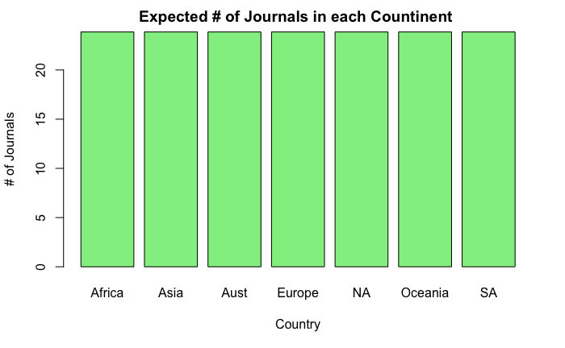

```r
#Bar Plot
E <- c(23.86,23.86,23.86,23.86,23.86,23.86,23.86)
CS <- c("Africa", "Asia", "Aust", "Europe", "NA", "Oceania", "SA")
barplot(E, names.arg = CS, xlab ="Country", ylab = " # of Journals", col = "light green", main = "Expected # of Journals in each Countinent ", border = "black")
```

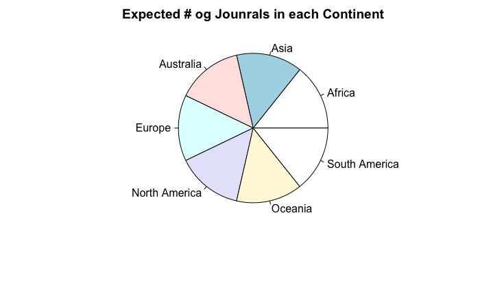

```r
#Pie Chart
slices <- c(23.86,23.86,23.86,23.86,23.86,23.86,23.86)
lbls <- c("Africa", "Asia", "Australia", "Europe", " North America", "Oceania", "South America")
pie(slices, labels = lbls, main="Expected # og Jounrals in each Continent")
```

2 Types of Chart of Observed Values

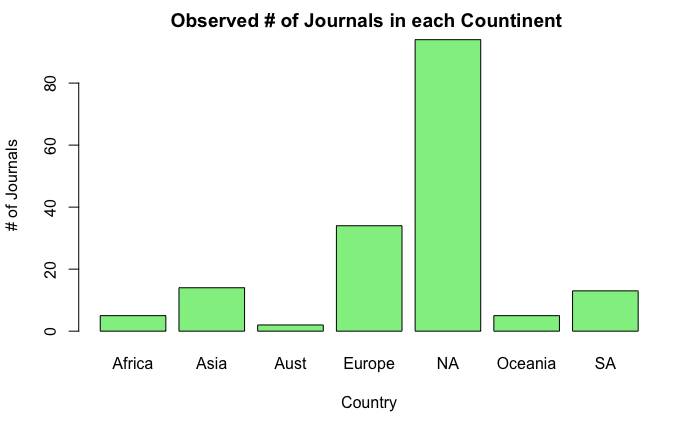

```r
#Bar Plot
E <- c(5,14,2,34,94,5,13)
CS <- c("Africa", "Asia", "Aust", "Europe", "NA", "Oceania", "SA")
barplot(E, names.arg = CS, xlab ="Country", ylab = " # of Journals", col = "light green", main = "Observed # of Journals in each Countinent ", border = "black")
```

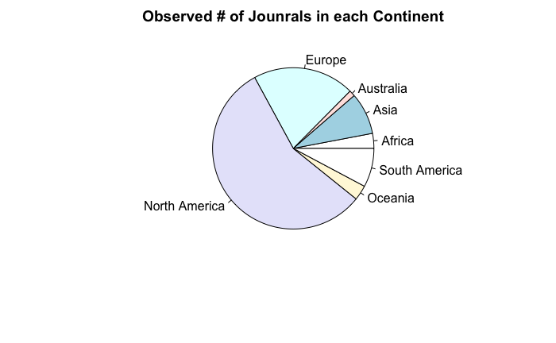

```r
#Pie Chart
slices <- c(5,14,2,34,94,5,13)
lbls <- c("Africa", "Asia", "Australia", "Europe", " North America", "Oceania", "South America")
pie(slices, labels = lbls, main="Observed # of Jounrals in each Continent")
```

Chi-Squared Tests for *CASE 2* (Square Mileage)

```r
sm.earth <- 197 # sqr miles of earths surface

sm.continent <- c(SqrMileage$`Sq. mi (million mi^2)`)

sm.continent <- as.numeric(sm.continent[2:8])

prop.cont <- sm.continent/sum(sm.continent)
prop.cont

#Chi-Squares
chisq.test(tally(continent.work), p=prop.cont)
xchisq.test(tally(continent.work),p=prop.cont )
```

[output not shown]

Chart of Expected Values based on Square Mileage

```r
#Bar Plot
E <- c(35.26, 51.73, 8.93, 11.82, 28.67 ,9.89 ,20.70)
CS <- c("Africa", "Asia", "Aust", "Europe", "NA", "Oceania", "SA")
barplot(E, names.arg = CS, xlab ="Country", ylab = " # of Journals", col = "blue", main = "Expected # of Journals in each Continent based on the Sq. Mileage", border = "black")
```

[output not shown]

Chart of Obseved Values based on Square Mileage

```r
#Bar Plot
O <- c(5,14,2,34,94,5,13)
C <- c("Africa", "Asia", "Aust", "Europe", "NA", "Oceania", "SA")
barplot(O, names.arg = C, xlab ="Country", ylab = " # of Journals", col = "blue", main = "Observed # of Journals in each Continent based on Sqr. Mileage", border = "black")
```

[output not shown]

# Country

# State

*CASE 1* (no Square mileage) HO: The probability of each State being represented in a journal entry is the same HA: The probability of each State being represented in a journal entry is not the same *Case 2* (with Square Mileage) HO: The probability of each State being represented in a journal entry is the same as square mileage HA: The probability of each State being represented in a journal entry is not the same as square mileage

Cleaning our data and using tally() function to view our numbers

```r
state.work <- as.vector(EcologyBias$`State or Municipality where the work was done`)
state.work
remove <- c ("Multiple States", "Multiple", "META ANALYSIS", "OR/CA", "GA/FL", "NY, MA, CT")
state.work %in% remove
state.work <- state.work [! state.work %in% remove]
state.work
state.work <- state.work[!is.na(state.work)]
state.work
```

[output not shown]

Chi Square Test *Case 1*

```r
tally(state.work)
xchisq.test(tally(state.work))
```

[output not shown]

Chart of State (Expected)

```r
state.EXP <- c(2.26,2.26,2.26,2.26,2.26,2.26,2.26,2.26,2.26,2.26,2.26,2.26,2.26,2.26,2.26,2.26,2.26,2.26,2.26,2.26,2.26,2.26,2.26,2.26,2.26,2.26,2.26)
state <- c("AK", "AL", "AZ", "CA", "CO", "FL", "HI", "IN", "KS", "MA", "MD", "MI", "MO", "MT", "NC", "NH", "NJ", "NM", "NY", "OH", "OR", "PR", "TX", "UT", "WA", "WI", "WY")
barPlot1 <- barplot(state.EXP, names.arg = state, xlab ="State", ylab = " # of Journals", col = "light green", main = "Expected # of Journals in each State", border = "black")
```

[output not shown]

Chart of State (Observed)

```r
state.obs <- c(2,2,3,13,2,4,1,1,2,1,1,4,1,1,1,1,2,1,1,1,4,2,3,1,3,1,2)
state <- c("AK", "AL", "AZ", "CA", "CO", "FL", "HI", "IN", "KS", "MA", "MD", "MI", "MO", "MT", "NC", "NH", "NJ", "NM", "NY", "OH", "OR", "PR", "TX", "UT", "WA", "WI", "WY")
barPlot1 <- barplot(state.obs, names.arg = state, xlab ="State", ylab = " # of Journals", col = "light green", main = "Observed # of Journals in each State ", border = "black")
```

[output not shown]

State with sqr mileage *Case 2*

```r
sm.state <- c(SqrMileage$`totalSQM`)
sm.state <- c(sm.state[1:27])
#sm.state
prop.state <- sm.state/sum(sm.state)
#prop.state
#Chi Square
xchisq.test(tally(state.work),p=prop.state  )
```

[output not shown]

Chart of State based on Square Mileage (Expected)

```r
state.exp <- c(15.290,1.221,2.656, 3.813, 2.425, 1.397, 0.150, 0.848, 1.917, 0.824, 0289, 2.255, 1.624, 3.425, 1.227, 0.218, 0.203, 2.832, 1.269, 1.044, 2.292, 0.082, 6.256, 1.978, 1.661, 1.526, 2.278)
state <- c("AK", "AL", "AZ", "CA", "CO", "FL", "HI", "IN", "KS", "MA", "MD", "MI", "MO", "MT", "NC", "NH", "NJ", "NM", "NY", "OH", "OR", "PR", "TX", "UT", "WA", "WI", "WY")
barPlot1 <- barplot(state.exp, names.arg = state, xlab ="State", ylab = " # of Journals", col = "light green", main = "Expected # of Journals in each State based on Sqr. Mileage", border = "black")
```

[output not shown]

Chart of State based on Square Mileage (Observed)

```r
state.obs <- c(2,2,3,13,2,4,1,1,2,1,1,4,1,1,1,1,2,1,1,1,4,2,3,1,3,1,2)
state <- c("AK", "AL", "AZ", "CA", "CO", "FL", "HI", "IN", "KS", "MA", "MD", "MI", "MO", "MT", "NC", "NH", "NJ", "NM", "NY", "OH", "OR", "PR", "TX", "UT", "WA", "WI", "WY")
barPlot1 <- barplot(state.obs, names.arg = state, xlab ="State", ylab = " # of Journals", col = "light green", main = "Observed # of Journals in each State based on Sqr. Mileage", border = "black")
```

[output not shown]

# Region